# Incarceration Data Visualization

Hanna Lee

2/22/2022

# Report

### Introduction

Incarceration is a multifaceted issue. From this dataset, I hope to extrapolate information from the story behind the numbers. My focus is on Washington state. I will evaluate the trends in the incarceration population in the BIPOC community for the current top 5 populous counties in Washington. Since Washington is labeled as a liberal state, I wanted to compare it to the most conservative state in the country, Mississippi. I first evaluated the jail population of Black people in Mississippi and Washington. Then, I wanted to see a further comparison with the incarceration population of Black and White people in Washington and Mississippi. These charts and maps will help us summarise the relationship between an inmate’s race and location.

### Summary of Information

The change in population in Mississippi from 1998 to 2018 was a increase of 1749.41 Black people in jail population.

The change in population in Washington from 1998 to 2018 was an increase of 261.25 Black people in jail population.

The current highest ratio of jail population in Black people in Washington state to Mississippi is 0.267.

The current highest ratio of jail population in White people in Washington state to Mississippi is 1.656.

In 2018, the Washington state county with the highest population of Black people in jail was King County.

In 2018, the Mississippi county with the highest population of Black people in jail was Hinds County.

### References:

Most Conservative States 2022. World Population Review. (n.d.). Retrieved February 24, 2022, from https://worldpopulationreview.com/state-rankings/most-conservative-states

Population of Counties in Washington (2022). World Population Review. (n.d.). Retrieved February 24, 2022, from https://worldpopulationreview.com/us-counties/states/wa

## Chart that Shows Trends Over Time

### County and BIPOC Jail Population

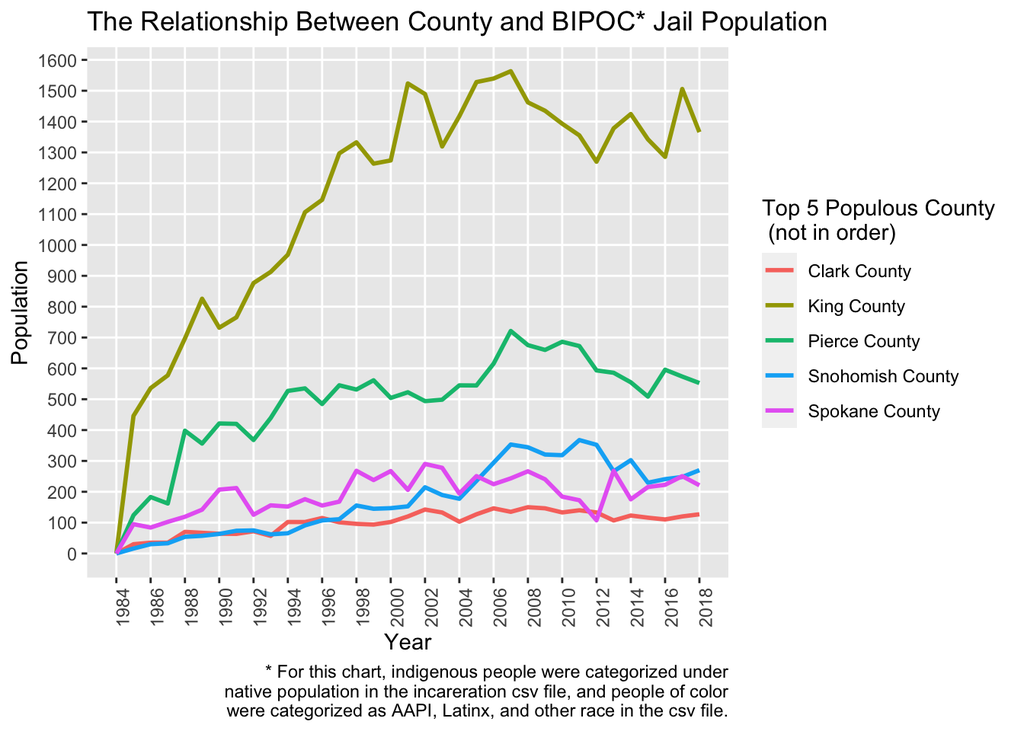

The top 5 populous county in Washington was chosen becuase it provided the great amount of information in the terms of diversity. Due to population of the counties, it allowed a level of depth that would not be seen in a smaller county. Not surprisingly, King county had higher levels of BIPIOC incarceration. It is the largest county in Washington and is a central hub for activism and social events. Due to the density, we’re seeing higher levels of incareration. Overall, we see a great snapshot into the dynamic of Washington state.

The top 5 counties was determined through the census and was compiled by World Population Review. The citation is listed in the references section.

## Chart that Compares Two Variables

### State and Jail Population of Black People

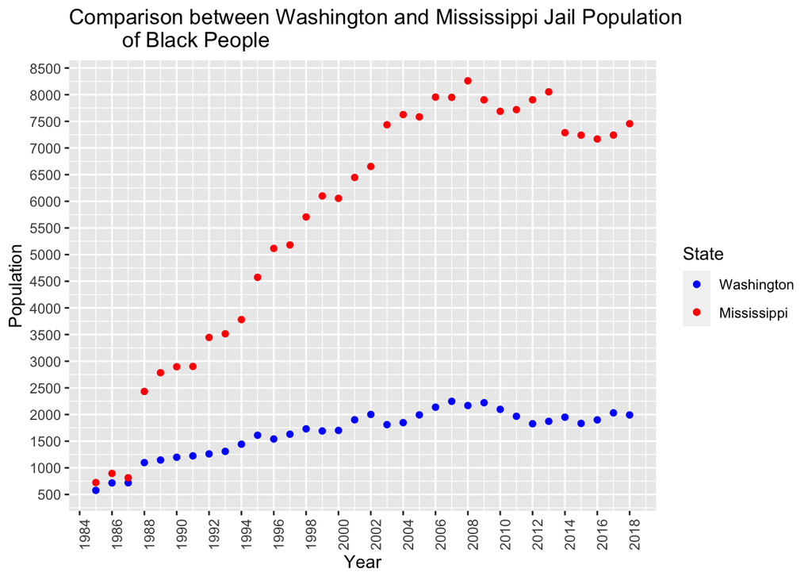

Washington state is considered a liberal state, and I believe comparing it to the most conservative state in the country would provide an insight into the dynamic of our country. Many factors are not listed in this dataset, so we utilize the incarceration number. This chart is a gateway to opportunities to study why this dramatic difference exists. There can be social, economic, or governmental factors that made this happen. We can see from 1988 on that Mississippi had a significantly higher incarceration population of Black people than Washington state. The steep incline from 1988 to 2002 in Mississippi is interesting to note because Washington did not see those types of increase or variation. In 2008, Mississippi had its maximum peak, which is also the year President Barack Obama took office. Based on this preliminary analysis of the data, we could pull in another dataset and explore if political leanings impact the incarceration population of Black people.

The most conservative state was determined through a Gallup poll and was compiled by World Population Review. The citation is listed in the references section.

## Map of Washington State and Mississippi

### State and Jail Population of Black and White People

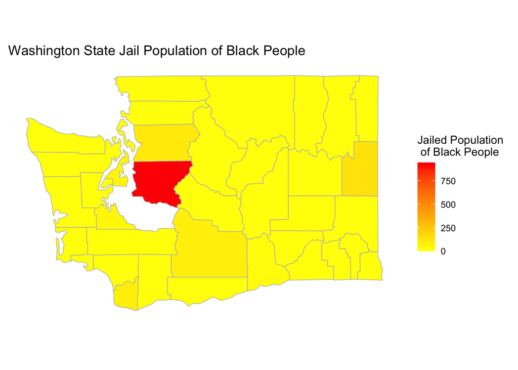

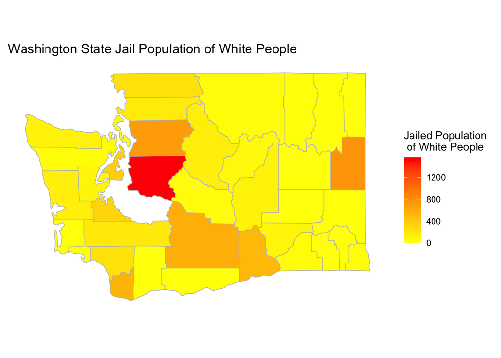

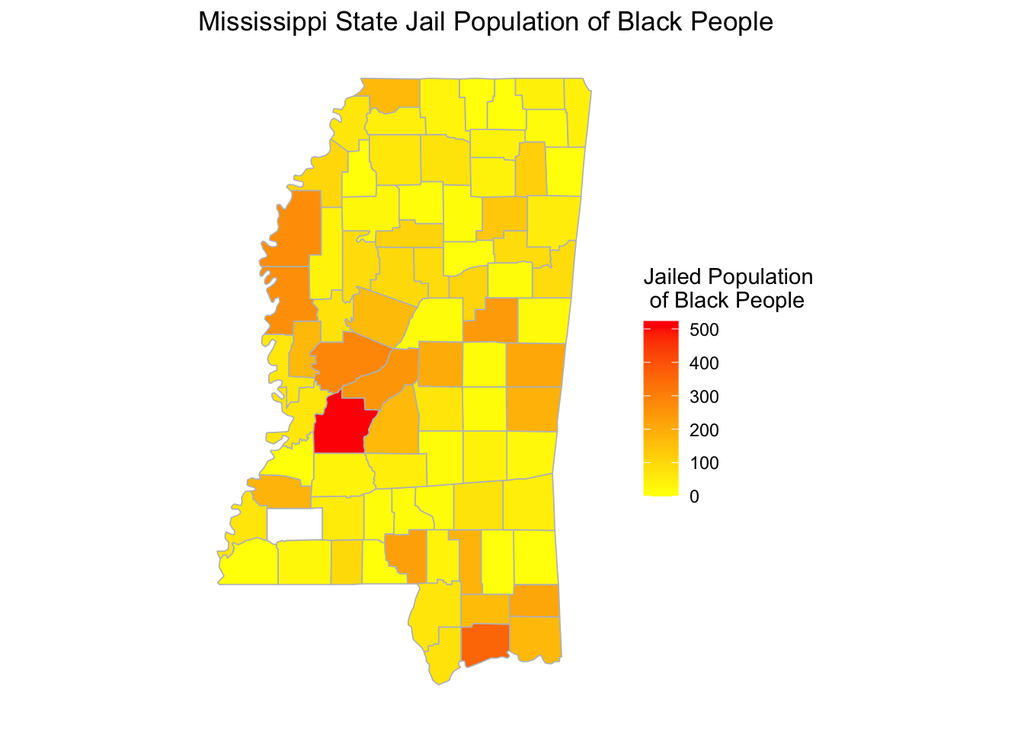

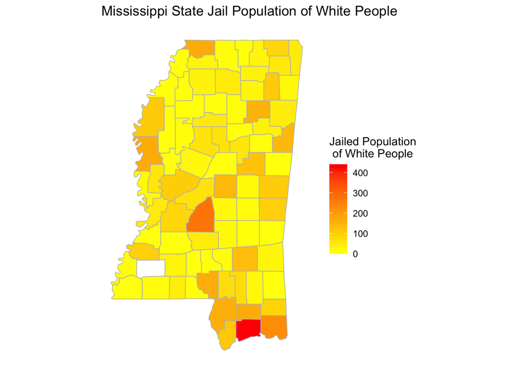